# R Notebook

```r
mod1a <- lm(price ~ sqft_living, data = houses_clean)
mod1b <- lm(price ~ sqft_above, data = houses_clean)

summary(mod1a)
```

```
Call:
lm(formula = price ~ sqft_living, data = houses_clean)

Residuals:
     Min       1Q   Median       3Q      Max
-1476062  -147486   -24043   106182  4362067

Coefficients:
              Estimate Std. Error t value Pr(>|t|)
(Intercept) -43580.743   4402.690  -9.899   <2e-16 ***
sqft_living    280.624      1.936 144.920   <2e-16 ***
---
Signif. codes:  0 ‘***’ 0.001 ‘**’ 0.01 ‘*’ 0.05 ‘.’ 0.1 ‘ ’ 1

Residual standard error: 261500 on 21611 degrees of freedom
Multiple R-squared:  0.4929,    Adjusted R-squared:  0.4928
F-statistic: 2.1e+04 on 1 and 21611 DF,  p-value: < 2.2e-16
```

```r
summary(mod1b)
```

```
Call:
lm(formula = price ~ sqft_above, data = houses_clean)

Residuals:
    Min      1Q  Median      3Q     Max
-913132 -165624  -41468  109327 5339232

Coefficients:
            Estimate Std. Error t value Pr(>|t|)
(Intercept)  59953.2     4729.8   12.68   <2e-16 ***
sqft_above     268.5        2.4  111.87   <2e-16 ***
---
Signif. codes:  0 ‘***’ 0.001 ‘**’ 0.01 ‘*’ 0.05 ‘.’ 0.1 ‘ ’ 1

Residual standard error: 292200 on 21611 degrees of freedom
Multiple R-squared:  0.3667,    Adjusted R-squared:  0.3667
F-statistic: 1.251e+04 on 1 and 21611 DF,  p-value: < 2.2e-16
```

In both of these models, the p values for the coefficients and intercepts are <2e-16, which is very small. The r2 value for mod1a is 0.4929, the r2 value for mod1b is 0.3667. mod1a is quite a lot higher, so we’re going to take mod1a going forward.

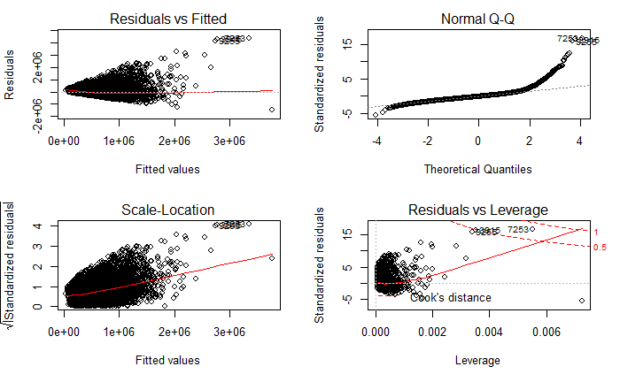

```r
par(mfrow = c(2, 2))
plot(mod1a)
```

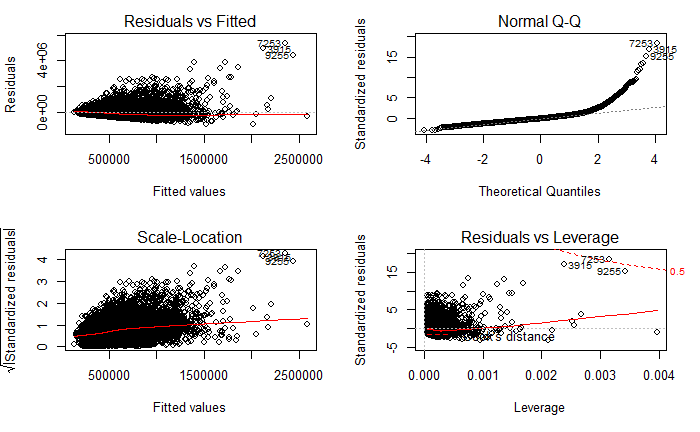

```r
par(mfrow = c(2, 2))
plot(mod1b)
```

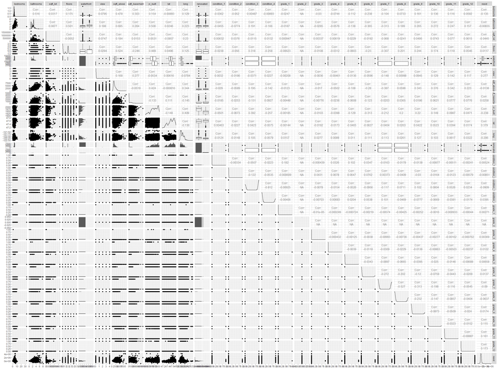

```r
price_remaining_resid <- houses_clean %>%
  add_residuals(mod1a) %>%
  select(-price, -sqft_living)

price_remaining_resid %>%
  ggpairs()
```

```r
beepr::beep(8)
```

based on this graph, I’m going to choose lat, view, and waterfront as my next models.

```r
mod2a <- lm(price ~ sqft_living + view, data = houses_clean)
mod2b <- lm(price ~ sqft_living + lat, data = houses_clean)
mod2c <- lm(price ~ sqft_living + waterfront, data = houses_clean)

summary(mod2a)
```

```
Call:
lm(formula = price ~ sqft_living + view, data = houses_clean)

Residuals:
     Min       1Q   Median       3Q      Max
-1583570  -139453   -19322   104245  4321083

Coefficients:
              Estimate Std. Error t value Pr(>|t|)
(Intercept) -16853.463   4257.279  -3.959 7.56e-05 ***
sqft_living    256.176      1.934 132.485  < 2e-16 ***
view        102951.162   2317.467  44.424  < 2e-16 ***
---
Signif. codes:  0 ‘***’ 0.001 ‘**’ 0.01 ‘*’ 0.05 ‘.’ 0.1 ‘ ’ 1

Residual standard error: 250300 on 21610 degrees of freedom
Multiple R-squared:  0.5353,    Adjusted R-squared:  0.5352
F-statistic: 1.245e+04 on 2 and 21610 DF,  p-value: < 2.2e-16
```

```r
summary(mod2b)
```

```
Call:
lm(formula = price ~ sqft_living + lat, data = houses_clean)

Residuals:
     Min       1Q   Median       3Q      Max
-1487994  -125643   -20309    84613  4368717

Coefficients:
              Estimate Std. Error t value Pr(>|t|)
(Intercept) -3.416e+07  5.653e+05  -60.44   <2e-16 ***
sqft_living  2.749e+02  1.794e+00  153.27   <2e-16 ***
lat          7.177e+05  1.189e+04   60.36   <2e-16 ***
---
Signif. codes:  0 ‘***’ 0.001 ‘**’ 0.01 ‘*’ 0.05 ‘.’ 0.1 ‘ ’ 1

Residual standard error: 241900 on 21610 degrees of freedom
Multiple R-squared:  0.566, Adjusted R-squared:  0.566
F-statistic: 1.409e+04 on 2 and 21610 DF,  p-value: < 2.2e-16
```

```r
summary(mod2c)
```

```
Call:
lm(formula = price ~ sqft_living + waterfront, data = houses_clean)

Residuals:
     Min       1Q   Median       3Q      Max
-1376782  -142867   -21360   107201  4449253

Coefficients:
                 Estimate Std. Error t value Pr(>|t|)
(Intercept)    -32957.851   4242.971  -7.768 8.35e-15 ***
sqft_living       272.507      1.873 145.499  < 2e-16 ***
waterfrontTRUE 829983.104  19882.279  41.745  < 2e-16 ***
---
Signif. codes:  0 ‘***’ 0.001 ‘**’ 0.01 ‘*’ 0.05 ‘.’ 0.1 ‘ ’ 1

Residual standard error: 251500 on 21610 degrees of freedom
Multiple R-squared:  0.5307,    Adjusted R-squared:  0.5307
F-statistic: 1.222e+04 on 2 and 21610 DF,  p-value: < 2.2e-16
```

From these models, mod2b has the highest r2 value at 0.566. It also has a p value of 2e-16 for both coefficientsa and the y intercept, which 2a and 2c don’t. In addition, it also has the highest adjusted r2 value. I’ll be using mod2b from here on.

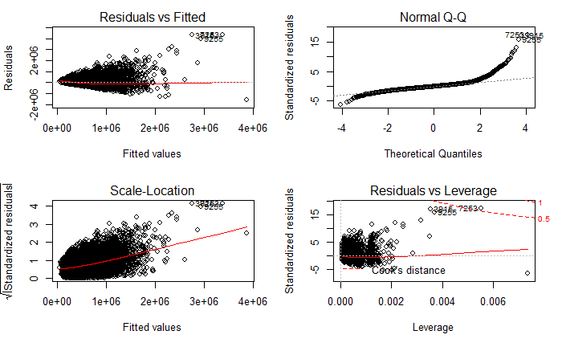

```r
par(mfrow = c(2, 2))
plot(mod2a)
```

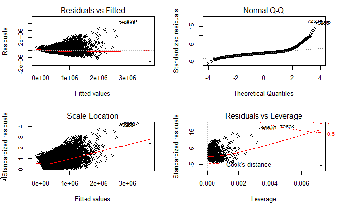

```r
par(mfrow = c(2, 2))
plot(mod2b)
```

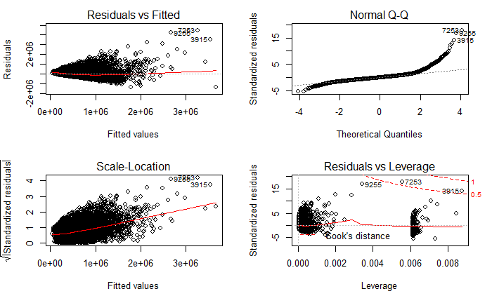

```r
par(mfrow = c(2, 2))
plot(mod2c)
```

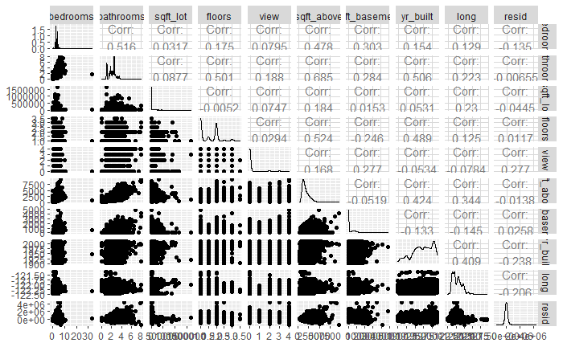

```r
price_remaining_resid <- houses_clean %>%
  add_residuals(mod1a) %>%
  select(-price, -sqft_living, -lat)

houses_numeric_resid <- price_remaining_resid %>%
  select(bedrooms:floors, view:long, resid)

houses_logical_resid <- price_remaining_resid %>%
  select(waterfront, renovated:grade_12, resid)

houses_numeric_resid %>%
  ggpairs()
```

```r
beepr::beep(8)
```

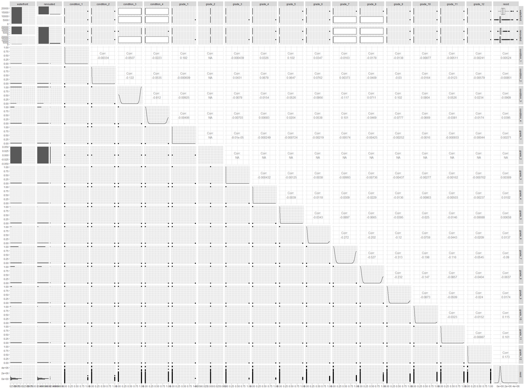

```r
houses_logical_resid %>%
  ggpairs()
```

```r
beepr::beep(8)
```

based on these two graphs, I’m going to run 3 different model 3s. mod3a view, mod3b yr_built, mod3c waterfront.

```r
mod3a <- lm(price ~ sqft_living + lat + view, data = houses_clean)
mod3b <- lm(price ~ sqft_living + lat + yr_built, data = houses_clean)
mod3c <- lm(price ~ sqft_living + lat + waterfront, data = houses_clean)

summary(mod2a)
summary(mod2b)
```

[output not shown]